# Forcast Qtr

Paisan Leewattana

2024-10-07

# About Time series

# Import data

```r
library(readxl)
library(ggplot2)
library(tidyverse)
library(dplyr)
library(tsibble)
library(fpp3)
library(latex2exp)
library(fable)
library(fabletools)
df<- read_excel("F:/Rwork/gdpfc.xlsx",sheet= "qtr")

print(df)
```

```
## # A tibble: 126 × 4
##    Y     Q         GDP Qtr
##    <chr> <chr>   <dbl> <chr>
##  1 1993  Q1    1067301 1993 Q1
##  2 1993  Q2    1039924 1993 Q2
##  3 1993  Q3    1086494 1993 Q3
##  4 1993  Q4    1147308 1993 Q4
##  5 1994  Q1    1179517 1994 Q1
##  6 1994  Q2    1146232 1994 Q2
##  7 1994  Q3    1135828 1994 Q3
##  8 1994  Q4    1226603 1994 Q4
##  9 1995  Q1    1265610 1995 Q1
## 10 1995  Q2    1256367 1995 Q2
## # ℹ 116 more rows
```

```r
df <- df |> mutate(Qtr=yearquarter(Qtr))|> as_tsibble(index = Qtr)
```

# Plots

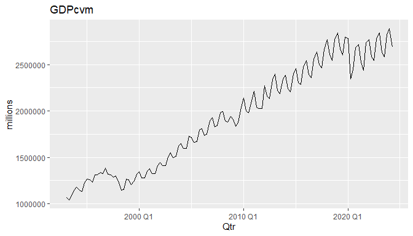

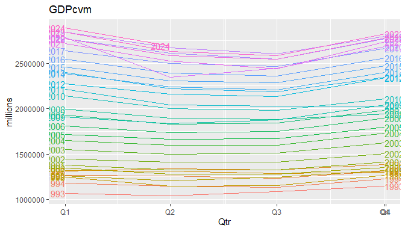

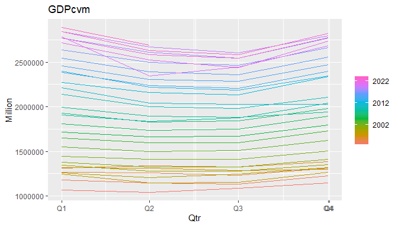

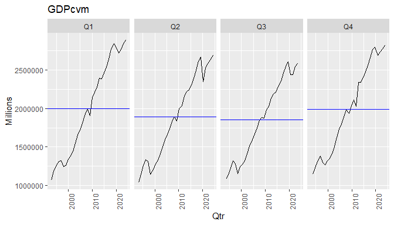

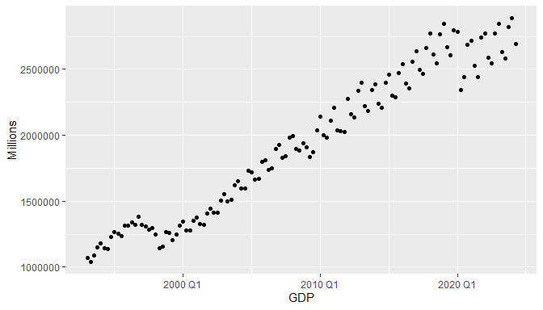

# Lag plot

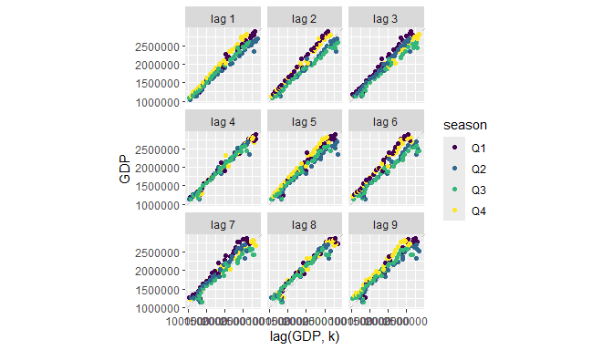

```r
df|>   gg_lag(GDP, geom = "point") +   labs(x = "lag(GDP, k)")
```

# Box-Cox transformations

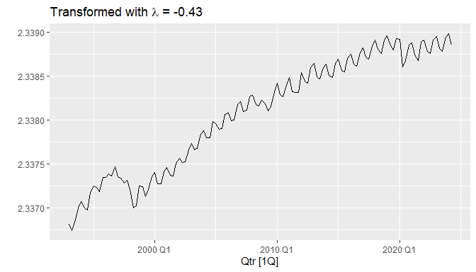

```r
lambda <- df |> features(GDP, features = guerrero) |>  pull(lambda_guerrero)
df|> autoplot(box_cox(GDP, lambda)) +
  labs(y = "", title = latex2exp::TeX(paste0("Transformed with $\\lambda$ = ", round(lambda,2))))
```

# Forecasting Decomposition

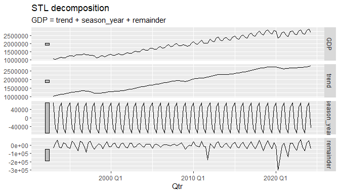

```r
df |> model(STL(GDP ~ trend(window = 7) +
                   season(window = "periodic"),
    robust = TRUE)) |>
  components() |>  autoplot()
```

```r
dcmp <- df |>  model(stl = STL(GDP))
components(dcmp)
```

| .model | Qtr | GDP | trend | season_year | remainder | season_adjust |
| --- | --- | --- | --- | --- | --- | --- |
| stl | 1993 Q1 | 1067301 | 1045644 | 18368.37 | 3288.22478 | 1048933 |
| stl | 1993 Q2 | 1039924 | 1072708 | -20687.42 | -12097.03060 | 1060611 |
| stl | 1993 Q3 | 1086494 | 1099351 | -29277.55 | 16420.92709 | 1115772 |
| stl | 1993 Q4 | 1147308 | 1126937 | 31698.68 | -11328.17324 | 1115609 |
| stl | 1994 Q1 | 1179517 | 1146871 | 18646.97 | 13998.57007 | 1160870 |
| stl | 1994 Q2 | 1146232 | 1162718 | -21200.79 | 4715.05955 | 1167433 |
| stl | 1994 Q3 | 1135828 | 1181038 | -29392.81 | -15816.94372 | 1165221 |
| stl | 1994 Q4 | 1226603 | 1206055 | 31986.91 | -11438.93897 | 1194616 |
| stl | 1995 Q1 | 1265610 | 1234710 | 18947.01 | 11952.95422 | 1246663 |
| stl | 1995 Q2 | 1256367 | 1257886 | -21715.91 | 20197.40498 | 1278083 |

[output cut: 116 more lines]

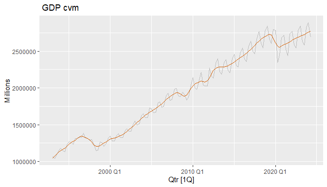

```r
components(dcmp) |>
  as_tsibble() |>
  autoplot(GDP, colour="gray") +
  geom_line(aes(y=trend), colour = "#D55E00") +
  labs( y = "Millions", title = " GDP cvm "
  )
```

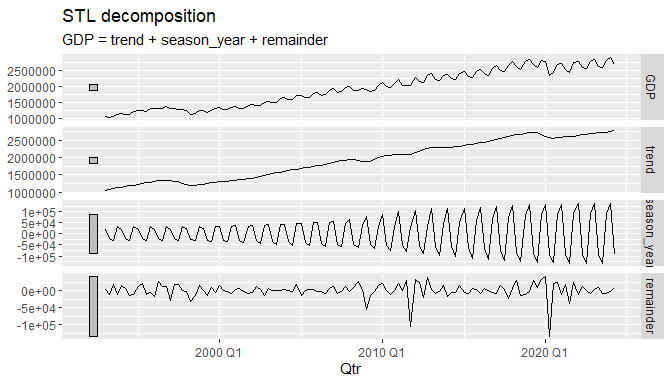

```r
components(dcmp) |> autoplot()
```

# Seasonally Adjusted data

yt-st additive yt/st multiplicative

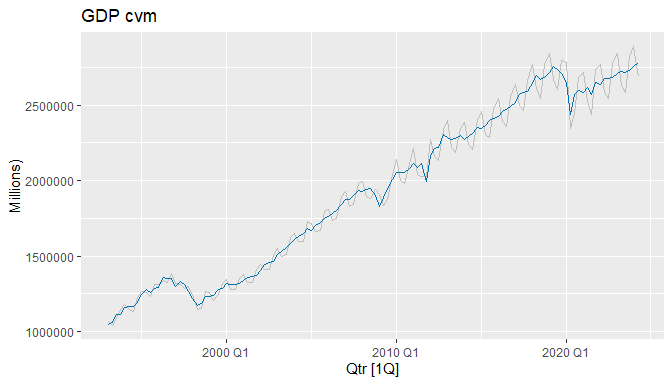

```r
components(dcmp) |>
  as_tsibble() |>
  autoplot(GDP, colour = "gray") +
  geom_line(aes(y=season_adjust), colour = "#0072B2") +
  labs(y = "Millions)",title = "GDP cvm")
```

# Forecast combination

Exponential Smoothing (ETS) and The seasonal-trend decomposition with Loess forecasting (STLF) is a method for decomposing time series (link https://laurentlsantos.github.io/forecasting/seasonal-and-trend-decomposition-with-loess-forecasting-model-stlf.html)

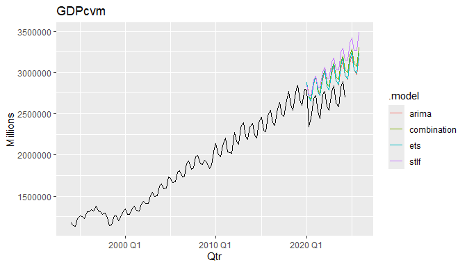

```r
train <- df |> filter(year(Qtr) <= 2019)
STLF <- decomposition_model(
  STL(log(GDP) ~ season(window = Inf)),
  ETS(season_adjust ~ season("N"))
)
GDP_models <- train |>
  model(
    ets = ETS(GDP),
    stlf = STLF,
    arima = ARIMA(GDP)
  ) |>
  mutate(combination = (ets + stlf + arima) / 3)
GDP_fc <- GDP_models |> forecast(h = "6 years")


GDP_fc |> autoplot(df|> filter(year(Qtr) > 1993), level = NULL) +  labs(y = "Millions",  title = "GDPcvm")
```

export data install.packages(“writexl”) library(“writexl”) write_xlsx(GDP_fc, “F:_fc.xlsx”)

```r
GDP_fc|> accuracy(df) |> arrange(RMSE)
```

| .model | .type | ME | RMSE | MAE | MPE | MAPE | MASE | RMSSE | ACF1 |
| --- | --- | --- | --- | --- | --- | --- | --- | --- | --- |
| arima | Test | -238152.5 | 244233.5 | 238152.5 | -9.064990 | 9.064990 | 3.002008 | 2.722840 | -0.3933367 |
| ets | Test | -244815.7 | 250014.9 | 244815.7 | -9.281751 | 9.281751 | 3.086000 | 2.787294 | -0.3254658 |
| combination | Test | -271280.4 | 278456.2 | 271280.4 | -10.292304 | 10.292304 | 3.419598 | 3.104372 | -0.1159424 |
| stlf | Test | -330872.9 | 344223.6 | 330872.9 | -12.530172 | 12.530172 | 4.170786 | 3.837581 | 0.2512616 |

RMSE and MAE : Choose ARIMA best model. Combination is not better

Forecast combination

distributions The GDP_fc object contains forecast distributions, from which any prediction interval can usually be computed. Let’s look at the intervals for the first period.

```r
GDP_fc|> filter(Qtr == min(Qtr))
```

| .model | Qtr | GDP | .mean |
| --- | --- | --- | --- |
| ets | 2020 Q1 |  | 2879403 |
| stlf | 2020 Q1 |  | 2845903 |
| arima | 2020 Q1 |  | 2882434 |
| combination | 2020 Q1 |  | 2869247 |

if we work with simulated sample paths, it is possible to create forecast distributions for the combination forecast as well.

```r
df_future <-GDP_models|>
  # Generate 1000 future sample paths
  generate(h = "5 years", times = 100) |>
  # Compute forecast distributions from future sample paths
  as_tibble() |>   group_by(Qtr, .model) |>
  summarise(dist = distributional::dist_sample(list(.sim)) )|>  ungroup() |>
  # Create fable object
  as_fable(index = Qtr, key = .model, distribution = dist, response = "GDP")
```

[output not shown]

```r
# Forecast distributions for h=1
df_future |> filter(Qtr == min(Qtr))
```

| Qtr | .model | dist |
| --- | --- | --- |
| 2020 Q1 | arima |  |
| 2020 Q1 | combination |  |
| 2020 Q1 | ets |  |
| 2020 Q1 | stlf |  |

four models, including the combination, are stored as empirical distributions, and we can plot prediction intervals for the combination forecast

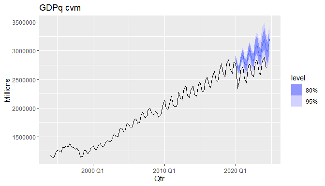

```r
df_future |> filter(.model == "combination") |>
  autoplot(df |> filter(year(Qtr) > 1993)) +
  labs(y = "Millions", title = "GDPq cvm")
```

# Check Accuracy by Winkle score

check the accuracy of the 95% prediction intervals, we can use a Winkler score

```r
df_future |>  accuracy(df, measures = interval_accuracy_measures, level = 95) |> arrange(winkler)
```

| .model | .type | winkler | pinball | scaled_pinball |
| --- | --- | --- | --- | --- |
| ets | Test | 1129490 | 56803.21 | 0.3580136 |
| stlf | Test | 2207528 | 64884.25 | 0.4089460 |
| combination | Test | 3540143 | 41166.21 | 0.2594583 |
| arima | Test | 4156314 | 40157.52 | 0.2531008 |